# Predictors of Diversity Outbred Cholesterol Levels

# 10 Mediating Effect of Body Weight

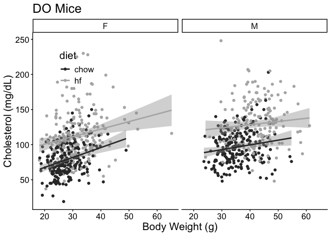

```r
ggplot(data=cholesterol.data,
       aes(y=chol2,
           x=bw.19,
           col=diet)) +
  geom_point() +
  facet_grid(.~sex) +
  geom_smooth(method=lm) +
    labs(y="Cholesterol (mg/dL)",
       x="Body Weight (g)",
       title="DO Mice") +
  scale_fill_grey() +
  scale_color_grey(end=0.7) +
  theme_classic() +
    guides(color=guide_legend(override.aes=list(fill=NA))) +
  theme(text=element_text(size=16),
        legend.position = c(0.15,0.80),
        legend.key=element_blank(),
        legend.background=element_blank())
```

```r
lm.bw.model.1 <- lm(chol2~sex+bw.19, data=cholesterol.data)

summary(lm.bw.model.1) %>% tidy %>% kable(caption="Effects of body weight on cholesterol at 18w, ajdusting for sex", digits=50)
```

Effects of body weight on cholesterol at 18w, ajdusting for sex

| term | estimate | std.error | statistic | p.value |
| --- | --- | --- | --- | --- |
| (Intercept) | 44.74 | 4.99 | 8.959 | 2.20e-18 |
| sexM | 2.06 | 2.56 | 0.803 | 4.22e-01 |
| bw.19 | 1.69 | 0.16 | 10.527 | 2.19e-24 |

```r
lm.bw.model.2 <- lm(chol2~sex+diet+bw.19, data=cholesterol.data)

summary(lm.bw.model.2) %>% tidy %>% kable(caption="Effects of body weight on cholesterol at 18w, ajdusting for sex and diet", digits=50)
```

Effects of body weight on cholesterol at 18w, ajdusting for sex and diet

| term | estimate | std.error | statistic | p.value |
| --- | --- | --- | --- | --- |
| (Intercept) | 55.859 | 4.554 | 12.27 | 7.51e-32 |
| sexM | 9.548 | 2.360 | 4.05 | 5.72e-05 |
| diethf | 29.317 | 2.093 | 14.01 | 4.36e-40 |
| bw.19 | 0.852 | 0.156 | 5.46 | 6.17e-08 |

```r
# mediating effect of body weight on the calcium, cholesterol relationship
lm.bw.1 <- lm(chol2~calcium2, data=cholesterol.data)
lm.bw.2 <- lm(chol2~calcium2+sex, data=cholesterol.data)
lm.bw.3 <- lm(chol2~calcium2+sex+bw.19, data=cholesterol.data)
lm.bw.4 <- lm(chol2~calcium2+sex+bw.19+diet, data=cholesterol.data)

bind_rows(tidy(lm.bw.1) %>% mutate(Model='cholesterol~calcium'),
          tidy(lm.bw.2) %>% mutate(Model='cholesterol~calcium+sex'),
          tidy(lm.bw.3) %>% mutate(Model='cholesterol~calcium+sex+body.weight'),
          tidy(lm.bw.4) %>% mutate(Model='cholesterol~calcium+sex+body.weight+diet')) %>%
  filter(term=='calcium2') %>%
  mutate(beta.calcium=paste(round(estimate,2),round(std.error,2),sep="+/-")) %>%
  select(Model,beta.calcium,p.value) %>%
  kable(caption="Summary of effects of body weight mediation",digits=c(0,0,99))
```

Summary of effects of body weight mediation

| Model | beta.calcium | p.value |
| --- | --- | --- |
| cholesterol~calcium | 14.37+/-1.03 | 2.17e-39 |
| cholesterol~calcium+sex | 14.55+/-0.99 | 1.75e-43 |
| cholesterol~calcium+sex+body.weight | 12.9+/-0.97 | 1.08e-36 |
| cholesterol~calcium+sex+body.weight+diet | 12.05+/-0.87 | 5.59e-39 |

## 10.1 Mediation Analysis for Body Weight

Did a mediation analysis for the effects of body weight on the calcium-cholesterol relationship. Based this on the instructions at https://data.library.virginia.edu/introduction-to-mediation-analysis/

```r
library(mediation)
#need a dataset that is complete with respect to calcium and cholesterol
mediation.cholesterol.data <-
  cholesterol.data %>%
  filter(!is.na(calcium2)) %>%
  filter(!is.na(chol2))
mediator.model <- lm(bw.19 ~ calcium2+sex, mediation.cholesterol.data)
model.full <- lm(chol2 ~ calcium2 + sex+bw.19, mediation.cholesterol.data)

bw.mediation.results <- mediate(mediator.model, model.full, treat='calcium2', mediator='bw.19',
                   boot=TRUE, sims=1000)
summary(bw.mediation.results)
```

```
##
## Causal Mediation Analysis
##
## Nonparametric Bootstrap Confidence Intervals with the Percentile Method
##
##                Estimate 95% CI Lower 95% CI Upper p-value
## ACME              1.648        1.002        2.410  <2e-16 ***
## ADE              12.903       11.364       14.787  <2e-16 ***
## Total Effect     14.552       12.929       16.514  <2e-16 ***
## Prop. Mediated    0.113        0.069        0.163  <2e-16 ***
## ---
## Signif. codes:  0 '***' 0.001 '**' 0.01 '*' 0.05 '.' 0.1 ' ' 1
##
## Sample Size Used: 765
##
##
## Simulations: 1000
```

Differences in body weight partially mediate the relationship between calcium and cholesterol.

# 11 Mediating Effect of Percent Fat Mass

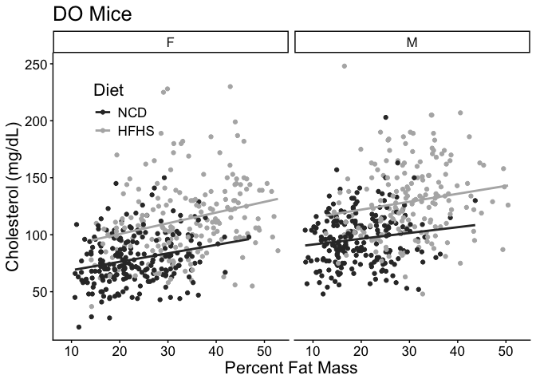

```r
ggplot(data=cholesterol.data,
       aes(y=chol2,
           x=percfat2*100,
           col=Diet)) +
  geom_point() +
  facet_grid(.~sex) +
  geom_smooth(method=lm,se=F) +
    labs(y="Cholesterol (mg/dL)",
       x="Percent Fat Mass",
       title="DO Mice") +
  scale_fill_grey() +
  scale_color_grey(end=0.7) +
  theme_classic() +
    guides(color=guide_legend(override.aes=list(fill=NA))) +
  theme(text=element_text(size=16),
        legend.position = c(0.15,0.80),
        legend.key=element_blank(),
        legend.background=element_blank())
```

```r
lm.bw.model.1 <- lm(chol2~sex+percfat2, data=cholesterol.data)

summary(lm.bw.model.1) %>% tidy %>% kable(caption="Effects of percent fat mass on cholesterol at 18w, ajdusting for sex", digits=50)
```

Effects of percent fat mass on cholesterol at 18w, ajdusting for sex

| term | estimate | std.error | statistic | p.value |
| --- | --- | --- | --- | --- |
| (Intercept) | 52.4 | 3.43 | 15.3 | 1.90e-46 |
| sexM | 21.8 | 2.11 | 10.3 | 1.25e-23 |
| percfat2 | 151.5 | 11.12 | 13.6 | 3.11e-38 |

```r
lm.bw.model.2 <- lm(chol2~sex+diet+percfat2, data=cholesterol.data)

summary(lm.bw.model.2) %>% tidy %>% kable(caption="Effects of percent fat mass on cholesterol at 18w, ajdusting for sex and diet", digits=50)
```

Effects of percent fat mass on cholesterol at 18w, ajdusting for sex and diet

| term | estimate | std.error | statistic | p.value |
| --- | --- | --- | --- | --- |
| (Intercept) | 61.5 | 3.30 | 18.66 | 0.00e+00 |
| sexM | 19.4 | 1.98 | 9.80 | 1.75e-21 |
| diethf | 25.9 | 2.31 | 11.20 | 3.51e-27 |
| percfat2 | 75.9 | 12.35 | 6.14 | 1.28e-09 |

### 11.0.1 Is there an effect of diet beyond the effect of fat mass?

```r
# mediating effect of body weight on the calcium, cholesterol relationship
lm.fm.1 <- lm(chol2~percfat2, data=cholesterol.data)
lm.fm.2 <- lm(chol2~sex+percfat2, data=cholesterol.data)
lm.fm.3 <- lm(chol2~sex+percfat2+diet, data=cholesterol.data)

bind_rows(tidy(lm.fm.1) %>% mutate(Model='cholesterol~sex'),
          tidy(lm.fm.2) %>% mutate(Model='cholesterol~sex+fat.mass'),
          tidy(lm.fm.3) %>% mutate(Model='cholesterol~sex+fat.mass+diet')) %>%
  filter(term=='percfat2') %>%
  mutate(beta.pct.fat.mass=paste(round(estimate,2),round(std.error,2),sep="+/-")) %>%
  dplyr::select(Model,beta.pct.fat.mass,p.value) %>%
  kable(caption="Summary of effects of diet and percent fat mass mediation",digits=c(0,0,99))
```

Summary of effects of diet and percent fat mass mediation

| Model | beta.pct.fat.mass | p.value |
| --- | --- | --- |
| cholesterol~sex | 130.28+/-11.62 | 3.18e-27 |
| cholesterol~sex+fat.mass | 151.53+/-11.12 | 3.11e-38 |
| cholesterol~sex+fat.mass+diet | 75.88+/-12.35 | 1.28e-09 |

```r
mediation.cholesterol.data <-
  cholesterol.data %>%
  filter(!is.na(calcium2)) %>%
  filter(!is.na(chol2)) %>%
  filter(!is.na(percfat2))

mediator.model <- lm(percfat2 ~ diet + sex, mediation.cholesterol.data)
model.full <- lm(chol2 ~ diet + sex + percfat2, mediation.cholesterol.data)

fm.mediation.results <- mediate(mediator.model, model.full, treat='diet', mediator='percfat2',
                   boot=TRUE, sims=1000)
summary(fm.mediation.results)
```

```
##
## Causal Mediation Analysis
##
## Nonparametric Bootstrap Confidence Intervals with the Percentile Method
##
##                Estimate 95% CI Lower 95% CI Upper p-value
## ACME              8.110        5.467       10.926  <2e-16 ***
## ADE              24.010       19.189       28.930  <2e-16 ***
## Total Effect     32.119       28.002       36.460  <2e-16 ***
## Prop. Mediated    0.252        0.170        0.342  <2e-16 ***
## ---
## Signif. codes:  0 '***' 0.001 '**' 0.01 '*' 0.05 '.' 0.1 ' ' 1
##
## Sample Size Used: 758
##
##
## Simulations: 1000
```

## 11.1 Mediation Analysis for Percent Fat Mass

Did a mediation analysis for the effects of percent fat mass on the calcium-cholesterol relationship. Based this on the instructions at https://data.library.virginia.edu/introduction-to-mediation-analysis/

```r
# mediating effect of body weight on the calcium, cholesterol relationship
lm.fm.1 <- lm(chol2~calcium2, data=cholesterol.data)
lm.fm.2 <- lm(chol2~calcium2+sex, data=cholesterol.data)
lm.fm.3 <- lm(chol2~calcium2+sex+percfat2, data=cholesterol.data)
lm.fm.4 <- lm(chol2~calcium2+sex+percfat2+diet, data=cholesterol.data)

bind_rows(tidy(lm.fm.1) %>% mutate(Model='cholesterol~calcium'),
          tidy(lm.fm.2) %>% mutate(Model='cholesterol~calcium+sex'),
          tidy(lm.fm.3) %>% mutate(Model='cholesterol~calcium+sex+fat.mass'),
          tidy(lm.fm.4) %>% mutate(Model='cholesterol~calcium+sex+fat.mass+diet')) %>%
  filter(term=='calcium2') %>%
  mutate(beta.calcium=paste(round(estimate,2),round(std.error,2),sep="+/-")) %>%
  dplyr::select(Model,beta.calcium,p.value) %>%
  kable(caption="Summary of effects of percent fat mass mediation",digits=c(0,0,99))
```

Summary of effects of percent fat mass mediation

| Model | beta.calcium | p.value |
| --- | --- | --- |
| cholesterol~calcium | 14.37+/-1.03 | 2.17e-39 |
| cholesterol~calcium+sex | 14.55+/-0.99 | 1.75e-43 |
| cholesterol~calcium+sex+fat.mass | 12.56+/-0.93 | 1.16e-37 |
| cholesterol~calcium+sex+fat.mass+diet | 12.04+/-0.87 | 2.72e-39 |

```r
#need a dataset that is complete with respect to calcium and cholesterol
mediation.cholesterol.data <-
  cholesterol.data %>%
  filter(!is.na(calcium2)) %>%
  filter(!is.na(chol2))
mediator.model <- lm(percfat2 ~ calcium2+sex, mediation.cholesterol.data)
model.full <- lm(chol2 ~ calcium2 + sex+percfat2, mediation.cholesterol.data)

bw.mediation.results <- mediate(mediator.model, model.full, treat='calcium2', mediator='percfat2',
                   boot=TRUE, sims=1000)
summary(bw.mediation.results)
```

```
##
## Causal Mediation Analysis
##
## Nonparametric Bootstrap Confidence Intervals with the Percentile Method
##
##                Estimate 95% CI Lower 95% CI Upper p-value
## ACME             2.0783       1.2632       2.9659  <2e-16 ***
## ADE             12.5614      10.9495      14.3331  <2e-16 ***
## Total Effect    14.6397      13.0510      16.2629  <2e-16 ***
## Prop. Mediated   0.1420       0.0873       0.2042  <2e-16 ***
## ---
## Signif. codes:  0 '***' 0.001 '**' 0.01 '*' 0.05 '.' 0.1 ' ' 1
##
## Sample Size Used: 758
##
##
## Simulations: 1000
```

# 12 Random Forests

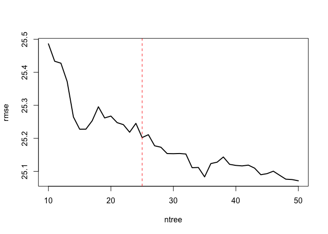

```r
library(caret)
library(ipred)

# Specify 10-fold cross validation
ctrl <- trainControl(method = "cv",  number = 10)

# train bagged model
bagged_cv <- bagging(
  formula = chol2~Diet+calcium2,
  data    = chol.pred.data.cont,
  coob=TRUE
  )

# assess 10-50 bagged trees
ntree <- 10:50

# create empty vector to store OOB RMSE values
rmse <- vector(mode = "numeric", length = length(ntree))

for (i in seq_along(ntree)) {
  # reproducibility
  set.seed(123)

  # perform bagged model
  model <- bagging(
  formula = chol2~Diet+sex+calcium2+tg2,
  data    = chol.pred.data.cont,
  coob=TRUE,
  nbagg   = ntree[i]
)
  # get OOB error
  rmse[i] <- model$err
}

plot(ntree, rmse, type = 'l', lwd = 2)
abline(v = 25, col = "red", lty = "dashed")
```

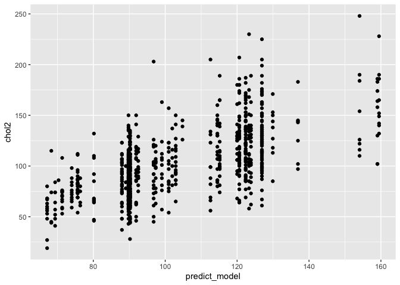

```r
predict_model<-predict(bagged_cv, chol.pred.data.cont)

ggplot(chol.pred.data.cont, aes(x=predict_model,y=chol2)) +
  geom_point()
```

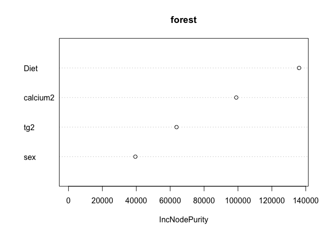

```r
library(randomForest)
forest <- randomForest(chol2~Diet+sex+calcium2+tg2,
             data = chol.pred.data.cont,
             na.action=na.exclude)
varImpPlot(forest)
```

```r
predict_model<-predict(forest, chol.pred.data.cont)
```

# 13 Cholesterol Associations with All Parameters

First estimated Spearman correlation coefficients for each parameter relative to chol2

```r
cholesterol.data %>%
  dplyr::select(-Diet,-sex,-coat.color,-mouse.id,-chol.avg,-High.Chol,-diet) %>%
  mutate_all(.funs=as.numeric) %>%
  cor(use="pairwise.complete.obs", method="spearman") %>%
  as.data.frame -> all.correlations

chol.correlations <- dplyr::select(all.correlations, chol2) %>%
  rownames_to_column('Parameter') %>%
  arrange(-abs(chol2))

cholesterol.data %>%
  dplyr::select(-Diet,-sex,-coat.color,-mouse.id,-chol.avg,-High.Chol,-diet) %>%
  mutate_all(.funs=as.numeric) %>%
  pivot_longer(cols=everything(),names_to="Parameter", values_to="Values") %>%
  group_by(Parameter) %>%
  summarize(n=length(Values[!(is.na(Values))])) ->
  chol.n

spearmentt <- function(r,n){r * sqrt((n-2)/((1-r)*(1+r)))} #from https://stats.stackexchange.com/questions/22816/calculating-p-value-for-spearmans-rank-correlation-coefficient-example-on-wikip

chol.cor.data <-
  left_join(chol.correlations,chol.n,by="Parameter") %>%
  mutate(cor.p.value = 2*pt(-abs(spearmentt(chol2,n)),n-2)) %>%
  mutate(cor.p.adj = p.adjust(cor.p.value,method="BH")) %>%
  rename(estimate=chol2)
```

Next constructed diet and sex adjusted linear models for each parameter

```r
cholesterol.data %>%
  dplyr::select(-coat.color,-mouse.id,-chol.avg,-High.Chol,-diet) %>%
  dplyr::select(b.area1:percfat2,nonhdlc1,nonhdlc2,sex,Diet) %>%
  pivot_longer(cols=-one_of('sex','Diet','chol2')) %>%
  group_by(name) %>%
  do(beta=as.numeric(unlist(tidy(lm(chol2~value+Diet+sex,data=.))[2,'estimate'])),
     se=as.numeric(unlist(tidy(lm(chol2~value+Diet+sex,data=.))[2,'std.error'])),
     lm.p.value=as.numeric(unlist(tidy(lm(chol2~value+Diet+sex,data=.))[2,'p.value']))) %>%
  mutate(lm.p.adj = p.adjust(lm.p.value,method="BH")) %>%
  mutate_if(is.list, as.numeric) -> chol.cor.lm

annotation.dictionary <- 'Svenson-183_Svenson_DO-dictionary.csv'
annotation.data <- read_csv(annotation.dictionary) %>%
  add_row(data_name="nonhdlc2", description="Non-HDL Cholesterol at 19 weeks") %>%
  add_row(data_name="nonhdlc1", description="Non-HDL Cholesterol at 8 weeks")

left_join(chol.cor.data,chol.cor.lm,by=c('Parameter'='name')) %>%
  left_join(dplyr::select(annotation.data, data_name, description), by=c('Parameter'='data_name')) %>%
  dplyr::select(-Parameter) %>%
  relocate(description, .before='estimate') %>%
  relocate(n, .before="estimate") %>%
  rename(Parameter = description) %>%
  filter(!is.na(Parameter)) %>%
  arrange(-abs(estimate)) -> cor.data.combined

cor.data.combined %>%
  kable(caption="Correlation coefficients and diet/sex adjusted estimates for each clinical parameter with cholesterol at 19 weeks",
        digits=c(0,3,3,99,99,3,3,99,99))
```

Correlation coefficients and diet/sex adjusted estimates for each clinical parameter with cholesterol at 19 weeks

| Parameter | n | estimate | cor.p.value | cor.p.adj | beta | se | lm.p.value | lm.p.adj |
| --- | --- | --- | --- | --- | --- | --- | --- | --- |
| Cholesterol at 19 weeks | 818 | 1.000 | 0.00e+00 | 0.00e+00 | NA | NA | NA | NA |
| High density lipoprotein at 19 weeks | 814 | 0.946 | 0.00e+00 | 0.00e+00 | 1.188 | 0.016 | 0.00e+00 | 0.00e+00 |
| Cholesterol at 8 weeks | 789 | 0.723 | 0.00e+00 | 0.00e+00 | 0.673 | 0.036 | 9.88e-64 | 9.88e-64 |
| High density lipoprotein at 8 weeks | 787 | 0.703 | 0.00e+00 | 0.00e+00 | 0.785 | 0.047 | 1.09e-53 | 1.09e-53 |
| Non-HDL Cholesterol at 19 weeks | 812 | 0.574 | 2.05e-72 | 6.87e-71 | 1.808 | 0.067 | 0.00e+00 | 0.00e+00 |
| Albumin to creatinine ratio at 20 weeks | 192 | 0.467 | 8.81e-12 | 2.79e-11 | NA | NA | NA | NA |
| Fat tissue mass at 21 weeks | 818 | 0.449 | 9.23e-42 | 2.15e-40 | 1.275 | 0.223 | 1.47e-08 | 1.47e-08 |
| Total tissue mass at 21 weeks | 818 | 0.448 | 1.02e-41 | 2.15e-40 | 0.779 | 0.144 | 8.89e-08 | 8.89e-08 |
| Weight at 21 weeks | 818 | 0.433 | 8.87e-39 | 1.24e-37 | 0.743 | 0.148 | 6.13e-07 | 6.13e-07 |
| Glucose at 19 weeks | 815 | 0.431 | 3.46e-38 | 4.14e-37 | 0.116 | 0.020 | 9.40e-09 | 9.40e-09 |
| Calcium, time 2 at 19 weeks | 768 | 0.417 | 1.08e-33 | 8.28e-33 | 12.579 | 0.866 | 2.31e-42 | 2.31e-42 |
| Fat tissue mass at 12 weeks | 832 | 0.404 | 5.41e-34 | 4.32e-33 | 1.034 | 0.329 | 1.75e-03 | 1.75e-03 |
| Non-HDL Cholesterol at 8 weeks | 787 | 0.400 | 1.29e-31 | 8.65e-31 | 1.254 | 0.108 | 7.35e-29 | 7.35e-29 |
| Total tissue mass at 12 weeks | 832 | 0.381 | 4.53e-30 | 2.72e-29 | 0.611 | 0.195 | 1.81e-03 | 1.81e-03 |
| Leptin at 8 weeks | 826 | 0.380 | 8.96e-30 | 5.19e-29 | 0.153 | 0.046 | 9.99e-04 | 9.99e-04 |
| Albumin to creatinine ratio at 11 weeks | 197 | 0.372 | 7.18e-08 | 1.85e-07 | NA | NA | NA | NA |
| Weight at 12 weeks | 832 | 0.368 | 3.92e-28 | 1.83e-27 | 0.645 | 0.198 | 1.20e-03 | 1.20e-03 |
| Glutamate dehydrogenase at 19 weeks | 766 | 0.338 | 5.63e-22 | 2.20e-21 | 0.577 | 0.077 | 2.12e-13 | 2.12e-13 |
| Insulin at 8 weeks | 821 | 0.328 | 4.22e-22 | 1.73e-21 | -0.053 | 0.019 | 5.66e-03 | 5.66e-03 |
| Lean tissue mass at 21 weeks | 818 | 0.296 | 4.67e-18 | 1.74e-17 | 0.966 | 0.289 | 8.81e-04 | 8.81e-04 |
| Glucose at 8 weeks | 741 | 0.270 | 7.06e-14 | 2.32e-13 | 0.028 | 0.027 | 2.93e-01 | 2.93e-01 |
| Adiponectin at 8 weeks | 195 | 0.263 | 2.00e-04 | 4.25e-04 | NA | NA | NA | NA |
| Lean tissue mass at 12 weeks | 832 | 0.262 | 1.76e-14 | 5.92e-14 | 0.731 | 0.336 | 2.98e-02 | 2.98e-02 |
| Total bilirubin at 19 weeks | 145 | 0.253 | 2.16e-03 | 4.17e-03 | 9.741 | 9.893 | 3.26e-01 | 3.26e-01 |
| Mouse length at 21 weeks | 819 | 0.246 | 9.60e-13 | 3.10e-12 | 5.842 | 2.592 | 2.45e-02 | 2.45e-02 |
| Non-esterified fatty acids at 19 weeks | 677 | 0.225 | 3.42e-09 | 9.74e-09 | 16.300 | 1.674 | 4.81e-21 | 4.81e-21 |
| Triglycericdes at 19 weeks | 819 | 0.207 | 2.38e-09 | 6.90e-09 | 0.177 | 0.017 | 3.77e-24 | 3.77e-24 |
| Phophorous at 19 weeks | 769 | 0.189 | 1.30e-07 | 3.25e-07 | 3.631 | 0.850 | 2.17e-05 | 2.17e-05 |
| Mouse length at 12 weeks | 832 | 0.188 | 4.72e-08 | 1.24e-07 | 3.804 | 2.637 | 1.50e-01 | 1.50e-01 |
| Mean corpuscular volume at 22 weeks | 601 | 0.142 | 4.89e-04 | 1.01e-03 | 0.501 | 0.395 | 2.06e-01 | 2.06e-01 |

[output cut: 52 more lines]

```r
write_csv(cor.data.combined,file="Correlation of clinical factors with cholesterol.csv")
```